# Hyperloop Data Analysis & Presentation Task

# 1. Setup

Import in the libraries I'm going to use.

```python
import numpy as np
import pandas as pd

import matplotlib.pyplot as plt
import holoviews as hv
from holoviews import opts, dim

from sklearn.ensemble import RandomForestRegressor
from sklearn.model_selection import train_test_split

from sklearn.metrics import mean_squared_error
from sklearn.metrics import mean_absolute_error
from math import sqrt

%matplotlib inline
```

### 1.1 Data Processing

Load the BART demand data for years 2017 and 2018 from http://64.111.127.166/origin-destination/

This data represents BART ridership by origin and destination (O-D) pairs. Each .csv file is compressed into a gz/gzip archive and contains five columns representing Day, Hour, Origin Station, Destination Station, and Trip Count. O-D pairs with a trip count of "zero" were ignored during file output to reduce file size.

I downloaded the gzip files locally and load the 2017 and 2018 data here.

```python
data2017_path = "/Users/michelleliu/Documents/Hyperloop/date-hour-soo-dest-2017.csv.gz"
data2018_path = "/Users/michelleliu/Documents/Hyperloop/date-hour-soo-dest-2018.csv.gz"

data2017 = pd.read_csv(data2017_path, compression = "gzip", header=None, names = ['Day', 'Hour', 'Origin', 'Destination','Count'])
data2018 = pd.read_csv(data2018_path, compression = "gzip", header=None, names = ['Day', 'Hour', 'Origin', 'Destination','Count'])
```

```python
data2017.head()
```

|  | Day | Hour | Origin | Destination | Count |
| --- | --- | --- | --- | --- | --- |
| 0 | 2017-01-01 | 0 | 12TH | 19TH | 1 |
| 1 | 2017-01-01 | 0 | 12TH | 24TH | 2 |
| 2 | 2017-01-01 | 0 | 12TH | BAYF | 1 |
| 3 | 2017-01-01 | 0 | 12TH | CIVC | 5 |
| 4 | 2017-01-01 | 0 | 12TH | COLS | 2 |

```python
data2018.head()
```

|  | Day | Hour | Origin | Destination | Count |
| --- | --- | --- | --- | --- | --- |
| 0 | 2018-01-01 | 0 | 12TH | 12TH | 3 |
| 1 | 2018-01-01 | 0 | 12TH | 16TH | 1 |
| 2 | 2018-01-01 | 0 | 12TH | BAYF | 1 |
| 3 | 2018-01-01 | 0 | 12TH | CAST | 3 |
| 4 | 2018-01-01 | 0 | 12TH | CIVC | 2 |

```python
data2017.tail()
```

|  | Day | Hour | Origin | Destination | Count |
| --- | --- | --- | --- | --- | --- |
| 9974090 | 2018-01-01 | 2 | WOAK | POWL | 3 |
| 9974091 | 2018-01-01 | 2 | WOAK | RICH | 1 |
| 9974092 | 2018-01-01 | 2 | WOAK | SBRN | 1 |
| 9974093 | 2018-01-01 | 2 | WOAK | SHAY | 2 |
| 9974094 | 2018-01-01 | 2 | WOAK | WOAK | 2 |

Here I notice that the 2017 data carry the same data for 2018-01-01 as the 2018 data, so I combine them and remove the duplicates.

```python
df = pd.concat([data2017,data2018]).drop_duplicates().reset_index(drop=True)
```

```python
print("2017 data contains", data2017.shape[0], "rows, of which", data2017[data2017['Day']=='2018-01-01'].shape[0], "are duplicate data.")
print("2018 data contains", data2018.shape[0], "rows.")

print("The final dataframe without duplicates has", df.shape[0], "rows.")
```

```
2017 data contains 9974095 rows, of which 2017 are duplicate data.
2018 data contains 10227631 rows.
The final dataframe without duplicates has 20199709 rows.
```

## 2. Plot

### A) Plot the average daily (from 0 to 24h) ridership pattern, averaging all O-D pairs. Comment the peaks.

Here we want the daily average count of ridership, so I am grouping just by the hour and calculating the ridership by hour.

```python
daily_avg = df.groupby('Hour').mean()
```

```python
daily_avg.T
```

| Hour | 0 | 1 | 2 | 3 | 4 | 5 | 6 | 7 | 8 | 9 | ... | 14 | 15 | 16 | 17 | 18 | 19 | 20 | 21 | 22 | 23 |
| --- | --- | --- | --- | --- | --- | --- | --- | --- | --- | --- | --- | --- | --- | --- | --- | --- | --- | --- | --- | --- | --- |
| Count | 3.730819 | 2.090049 | 8.787165 | 3.359798 | 3.041866 | 5.587964 | 9.459538 | 17.315303 | 22.938304 | 17.827334 | ... | 8.832404 | 10.70919 | 15.126 | 21.920304 | 20.133298 | 12.248011 | 7.921341 | 6.603006 | 6.033341 | 5.473457 |

1 rows × 24 columns

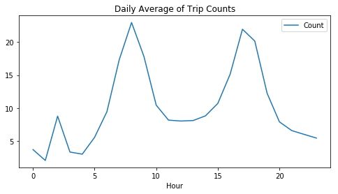

```python
daily_avg.plot(figsize=(8, 4), title="Daily Average of Trip Counts")
```

There are two peaks at around 8AM and 5PM, which makes sense for rush hour BART traffic.

### B) Plot the hourly ridership for 2 years (hour by hour for 2 years) for the 5 highest average ridership O-D pairs.

To find the 5 highest average ridership Origin-Destination pair, I group them by the Origin and Destination, take the average of the counts over the 2 years for each pair, and sort them by the average to get the top 5.

```python
OD_Pair = df.groupby(['Origin', 'Destination'])['Count'].mean().sort_values()
```

```python
OD_Pair.tail(5)
```

```
Origin  Destination
BALB    POWL            88.656430
24TH    MONT            90.085338
DUBL    EMBR           100.168548
POWL    BALB           102.431493
BALB    MONT           104.140755
Name: Count, dtype: float64
```

From this, we can see that the top 5 highest average ridership O-D pairs are:

- BALB - POWL
- 24TH - MONT
- DUBL - EMBR
- POWL - BALB
- BALB - MONT

Then because we want to plot hour by hour for 2 years, I combine the Day and the Hour to form a Datetime field, and also a field for the Origin-Destionation pair. I also put in the top 5 O-D pair to filter down the dataframe to just have informations for the 5 pairs to care about.

```python
df['Datetime'] = pd.to_datetime(df.Day) + pd.to_timedelta(df.Hour, unit='h')
df['O-D'] = df.Origin+'-'+df.Destination
top5_od_pair = ['BALB-POWL','24TH-MONT','DUBL-EMBR','POWL-BALB','BALB-MONT']
top5_df = df[df['O-D'].isin(top5_od_pair)]
```

```
Text(0.5,1,'Hourly Ridership For Top 5 O-D Pair')
```

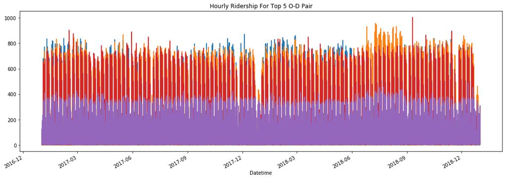

```python
fig, ax = plt.subplots()
top5_df.groupby('O-D').plot(x='Datetime', y='Count', ax=ax, figsize=(18,6), legend=False)
ax.set_title("Hourly Ridership For Top 5 O-D Pair" )
```

Plotting the top 5 O-D pair together seems too hard to see, so let's try plotting them into 5 subplots separately.

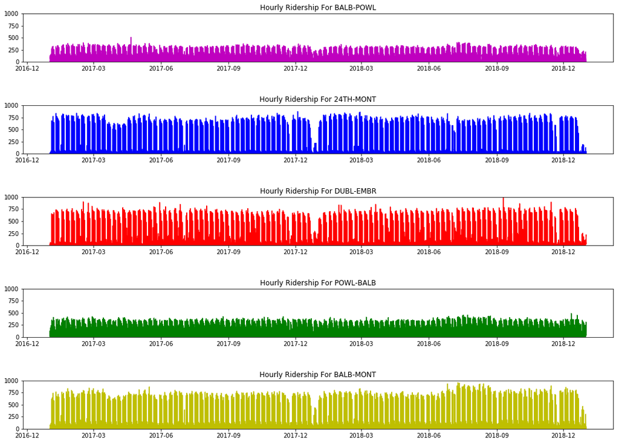

```python
fig, axs = plt.subplots(5,1, figsize=(18, 10))

color = ['m','b','r','g','y']

for i, od_pair in enumerate(top5_od_pair):
    df0 = top5_df[top5_df['O-D']==od_pair]
    axs[i].plot(df0['Datetime'], df0['Count'], color=color[i])
    axs[i].set_title("Hourly Ridership For " +top5_od_pair[i])
    axs[i].set(ylim=(0, 1000))
    plt.subplots_adjust(top = 0.99, bottom=0.01, hspace=0.9, wspace=0.4)
```

Here we can see an interesting pattern where POWL-BALB and BALB-POWL are pretty consistent in maintaining the average rides per hour where the other 3 O-D pairs see a larger surge and drop. We can see that the variance in the data depends on the O-D Pairs.

### C) Plot the distribution of the trains travelled between disctricts (NOT O-D pairs). We'd like to see yearly ridership or average per hour. The district map can be found here: https://www.bart.gov/about/bod/districts . Additional points for a Chord plot usage.

From the district map interactive feature, I copy over the station info for each district:

- **District 1**: Concord, Lafayette, Pleasant Hill/Contra Costa Centre, Walnut Creek
- **District 2**: North Concord/Martinez, Pittsburg/Bay Point, Pittsburg Center, Antioch
- **District 3**: Bay Fair, Downtown Berkeley, El Cerrito del Norte (partial), El Cerrito Plaza (partial), North Berkeley, Orinda, Rockridge, San Leandro
- **District 4**: Coliseum/Oakland Airport, Fruitvale, Lake Merritt, 12th Street/Oakland City Center, 19th Street/Oakland, MacArthur (partial)
- **District 5**: Castro Valley, Dublin/Pleasanton, Hayward, West Dublin/Pleasanton
- **District 6**: Fremont, South Hayward, Union City, Warm Springs
- **District 7**: Ashby, El Cerrito del Norte (partial), El Cerrito Plaza (partial), MacArthur (partial), Montgomery (partial), Richmond, West Oakland, Embarcadero (partial)
- **District 8**: Balboa Park (partial), Embarcadero (partial), Montgomery (partial),
- **District 9**: 16th Street Mission, 24th Street Mission, Glen Park, Civic Center, Powell Street, Balboa Park (partial)

Note that some stations can belong to two districts. In this case, I will map it to the district with a higher number. For example, Balboa Park is partially 8 and partially 9, so I will map it to District 9.

There are 48 unique origin/destination in the data set, so here I manually map each station's acronym to the district. There are 6 stations south of San Francisco that appear in the data set that do not correspond to any district according to the website - I will group them as a new district, District 10.

- **District 1**
  - CONC, LAFY, PHIL, WCRK
- **District 2**
  - NCON, PCTR, ANTC, PITT
- **District 3**
  - BAYF, DBRK, NBRK, ORIN, ROCK, SANL
- **District 4**
  - 12TH, 19TH, COLS, FTVL, LAKE, OAKL
- **District 5**
  - CAST, DUBL, HAYW, WDUB
- **District 6**
  - FRMT, SHAY, UCTY, WARM
- **District 7**
  - ASHB, DELN, MCAR, PLZA, RICH, WOAK
- **District 8**
  - BALB, EMBR, MONT
- **District 9**
  - 16TH, 24TH, CIVC, GLEN, POWL
- **Distrinct 10**
  - COLM, DALY, SBRN, SFIA, SSAN, MLBR

Then I assign 2 new columns, Origin District (O_district) & Destination District (D_district) to every row in our dataframe with the code below.

```python
#Districts from 1 to 10 in order
districts = [['CONC', 'LAFY', 'PHIL', 'WCRK'],
['NCON', 'PCTR', 'ANTC', 'PITT'],
['BAYF', 'DBRK', 'NBRK', 'ORIN', 'ROCK', 'SANL'],
['12TH', '19TH', 'COLS', 'FTVL', 'LAKE', 'OAKL'],
['CAST', 'DUBL', 'HAYW', 'WDUB'],
['FRMT', 'SHAY', 'UCTY', 'WARM'],
['ASHB', 'DELN', 'MCAR', 'PLZA', 'RICH', 'WOAK'],
['BALB', 'EMBR', 'MONT'],
['16TH', '24TH', 'CIVC', 'GLEN', 'POWL'],
['COLM', 'DALY', 'SBRN', 'SFIA', 'SSAN', 'MLBR']]

#initialize to 0 district (there should be none)
df['O_district'] = 0
df['D_district'] = 0

district_counter = 1
for d in districts:

    df.loc[df.Origin.isin(d),'O_district'] = district_counter
    df.loc[df.Destination.isin(d),'D_district'] = district_counter
    district_counter =district_counter + 1
```

```python
df.head()
```

|  | Day | Hour | Origin | Destination | Count | Datetime | O-D | O_district | D_district |
| --- | --- | --- | --- | --- | --- | --- | --- | --- | --- |
| 0 | 2017-01-01 | 0 | 12TH | 19TH | 1 | 2017-01-01 | 12TH-19TH | 4 | 4 |
| 1 | 2017-01-01 | 0 | 12TH | 24TH | 2 | 2017-01-01 | 12TH-24TH | 4 | 9 |
| 2 | 2017-01-01 | 0 | 12TH | BAYF | 1 | 2017-01-01 | 12TH-BAYF | 4 | 3 |
| 3 | 2017-01-01 | 0 | 12TH | CIVC | 5 | 2017-01-01 | 12TH-CIVC | 4 | 9 |
| 4 | 2017-01-01 | 0 | 12TH | COLS | 2 | 2017-01-01 | 12TH-COLS | 4 | 4 |

I make the assumption that "average per hour" is the average ridership between districts by the hour, so the dataframe would be grouped by the Origin District, Destination District, and Hour - and find the average of the counts.

```python
df.groupby(['O_district','D_district','Hour'])['Count'].mean()
```

```
O_district  D_district  Hour
1           1           0        2.008594
                        1        1.301153
                        2        1.307692
                        3        1.555556
                        4        1.514286
                        5        2.835950
                        6        5.588363
                        7        8.735229
                        8        8.350543
                        9        5.749597
                        10       4.582448
                        11       3.967607
                        12       4.363290
                        13       4.679163
```

[output cut: 48 more lines]

I also assume that "yearly ridesrhip" is the total amount of trips traveled between district by the year (2017 and 2018 in our case).

```python
df.groupby([df.Datetime.dt.year,'O_district','D_district'])['Count'].sum()
```

```
Datetime  O_district  D_district
2017      1           1              483705
                      2              271832
                      3              398327
                      4              846779
                      5               37904
                      6               59847
                      7              263860
                      8             2986467
                      9             1244636
                      10             356430
          2           1              273486
                      2               57838
                      3              115682
                      4              371944
```

[output cut: 48 more lines]

To do the Chord plot, I use the holoviews library that uses Bokeh to make the visualization.

```python
hv.extension('bokeh')
hv.output(size=200)
```

```python
links2017 = df[df.Datetime.dt.year==2017].groupby(['O_district','D_district'], as_index=False)['Count'].sum()
links2018 = df[df.Datetime.dt.year==2018].groupby(['O_district','D_district'], as_index=False)['Count'].sum()
```

```python
links2017.head()
```

|  | O_district | D_district | Count |
| --- | --- | --- | --- |
| 0 | 1 | 1 | 483705 |
| 1 | 1 | 2 | 271832 |
| 2 | 1 | 3 | 398327 |
| 3 | 1 | 4 | 846779 |
| 4 | 1 | 5 | 37904 |

```python
node_df = pd.DataFrame({"Name":['District1','District2','District3','District4','District5','District6','District7',
                                'District8','District9','District10'],
                    "Group":[1,2,3,4,5,6,7,8,9,10]})
node_df.head()
```

|  | Name | Group |
| --- | --- | --- |
| 0 | District1 | 1 |
| 1 | District2 | 2 |
| 2 | District3 | 3 |
| 3 | District4 | 4 |
| 4 | District5 | 5 |

```python
nodes = hv.Dataset(node_df,'Group','Name')
nodes.data
```

|  | Name | Group |
| --- | --- | --- |
| 0 | District1 | 1 |
| 1 | District2 | 2 |
| 2 | District3 | 3 |
| 3 | District4 | 4 |
| 4 | District5 | 5 |
| 5 | District6 | 6 |
| 6 | District7 | 7 |
| 7 | District8 | 8 |
| 8 | District9 | 9 |
| 9 | District10 | 10 |

#### Distribution of the trains travelled between districts - Yearly Ridership 2017

```python
chord2017 = hv.Chord((links2017, nodes),['O_district','D_district'],['Count'])
chord2017.opts(
    opts.Chord(cmap='Category20', edge_cmap='Category20', edge_color=dim('O_district').str(),
               labels='Name', node_color=dim('Name').str()))
```

[interactive chart not shown]

#### Distribution of the trains travelled between districts - Yearly Ridership 2018

```python
chord2018 = hv.Chord((links2018, nodes),['O_district','D_district'],['Count'])
chord2018.opts(
    opts.Chord(cmap='Category20', edge_cmap='Category20', edge_color=dim('O_district').str(),
               labels='Name', node_color=dim('Name').str()))
```

[interactive chart not shown]

## 3. Modeling - Predicting demand

### D) BONUS: try to create a demand prediction model.

Given the clean data, I don't have to do too much processing - I want to predict the demand based on the O-D pair and features such as day of the week, month, hour of travel. We saw earlier that Hour and O-D pair plays a part in determining ridership. Let's do some quick EDA just to check that day of the week and month do as well.

```
Text(0.5,0,'Month')
```

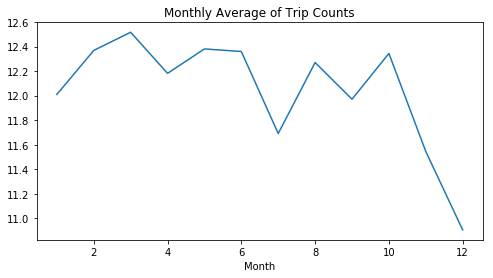

```python
ax = df.groupby([df.Datetime.dt.month]).Count.mean().plot(figsize=(8, 4), title="Monthly Average of Trip Counts")
ax.set_xlabel("Month")
```

```
Text(0.5,0,'Day of the Week')
```

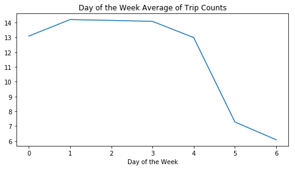

```python
ax = df.groupby([df.Datetime.dt.dayofweek]).Count.mean().plot(figsize=(8, 4), title="Day of the Week Average of Trip Counts")
ax.set_xlabel("Day of the Week")
```

From this we can see that ridership drops a bit in December, and also drops significantly on the weekend. Both look like good feature to include in our model.

### 3.1 Data Manipulation

I'm adding in Day of the Week and Month as features, and just sampling 50 of the top O-D pair (similar to the top 5 found in previous steps) due to memory/time constraint. There are more than 2000 unique O-D pair and the data was too large for me to test in Jupyter Notebook environment. I'm just using the 2017 dataset to train, also due to memory/time constraint.

```python
OD_Pair = df.groupby(['Origin', 'Destination'])['Count'].mean().sort_values().tail(50).reset_index()
```

```python
top50_pairs = OD_Pair.Origin+'-'+OD_Pair.Destination
```

```python
#training = df.copy()
training = df[df.Datetime.dt.year==2017]
training =training[df['O-D'].isin(top50_pairs)]
```

```python
training.shape
```

```
(355307, 9)
```

```python
#create categorical variables for Day of Week and Month
training['DOW']=training.Datetime.dt.dayofweek
training['Month']=training.Datetime.dt.month
```

```python
#create dummy variables for O-D and concat with rest of dataframe
training = pd.concat([training[['DOW','Month','Hour','Count']],pd.get_dummies(training['O-D'])],axis=1)
```

I created dummy variables for the O-D pairs since the model would not take in string categorical variables. Ideally, we would want to turn DOW, Month, and Hour into dummy variables too but it will create way too many columns to process in the limited environment.

### 3.2 Training & Testing Data¶

For the purpose of this assignment, I will randomly split our data into test and train, with a 80/20 split.

```python
X=training.drop('Count',axis=1)
y=training['Count']

X_train, X_test, y_train, y_test = train_test_split(X, y, test_size=0.2, random_state=42)
```

```python
print("training set size is: ", X_train.shape)
print("test set size is: ", X_test.shape)
```

```
training set size is:  (284245, 53)
test set size is:  (71062, 53)
```

### 3.3 Choosing the algorithm

I decided to go with Random Forest because:

- they are easy to understand and easy to implement
- scalable
- the columns don't need to be scaled - no normalization needed
- RF can capture non-linear relationships (which is evident in the EDA)
- RF is robust against overfitting, which is also likely given the EDA

Here, I'm using scikit-learn's Random Forest Regressor.

```python
#create model instance
model = RandomForestRegressor(n_estimators = 100, random_state = 42, n_jobs=-1)
#fit model
model.fit(X_train,y_train)
```

```
RandomForestRegressor(bootstrap=True, criterion='mse', max_depth=None,
           max_features='auto', max_leaf_nodes=None,
           min_impurity_decrease=0.0, min_impurity_split=None,
           min_samples_leaf=1, min_samples_split=2,
           min_weight_fraction_leaf=0.0, n_estimators=100, n_jobs=-1,
           oob_score=False, random_state=42, verbose=0, warm_start=False)
```

### 3.4 Model Evaluation

Since this is not a classifier, we cannot use the ratio of number of correct predictions to the total number of prediction to determine accuracy. We can look at the absoltue error and the root mean squared error to determine model performance. We can also use Mean Absolute Percentage Error (MAPE), a measure of prediction accuracy of a forecasting, to determine how well our model is doing.

```python
#preformance metrics
predictions = model.predict(X_test)
print('Mean Absolute Error:', mean_absolute_error(y_test, predictions))
print('Mean Squared Error:', mean_squared_error(y_test, predictions))
print('Root Mean Squared Error:', np.sqrt(mean_squared_error(y_test, predictions)))
mape = np.mean(np.abs((y_test - predictions) / np.abs(y_test)))
print('Mean Absolute Percentage Error:', round(mape * 100, 2))
print('Accuracy:', round(100*(1 - mape), 2))
```

```
Mean Absolute Error: 13.5638240893
Mean Squared Error: 1087.22911879
Root Mean Squared Error: 32.9731575496
Mean Absolute Percentage Error: 51.28
Accuracy: 48.72
```

The model is not great, but this is just the first pass with a out of the box model (I only changed the n_estimators paramter here).

### 3.5 Hyperparameter Tuning

Next, I try to use parameter tuning to improve the performance - there is a lot of parameters within the random forest model, so I picked a few that seems the most important.

- n_estimators = number of trees in the foreset
- max_features = max number of features considered for splitting a node
- max_depth = max number of levels in each decision tree
- min_samples_split = min number of data points placed in a node before the node is split
- min_samples_leaf = min number of data points allowed in a leaf node
- bootstrap = method for sampling data points (with or without replacement)

#### 3.5.1 Random Search

With RandomizedSearchCV, it is selecting at random a wide range of values as parameters, using 3 fold cross validation.

```python
from sklearn.model_selection import RandomizedSearchCV

n_estimators = [int(x) for x in np.linspace(start = 200, stop = 2000, num = 5)]
max_features = ['auto', 'sqrt']
max_depth = [int(x) for x in np.linspace(10, 110, num = 5)]
max_depth.append(None)
min_samples_split = [2, 5, 10]
min_samples_leaf = [1, 2, 4]
bootstrap = [True, False]

# Create the random grid
random_grid = {'n_estimators': n_estimators,
               'max_features': max_features,
               'max_depth': max_depth,
               'min_samples_split': min_samples_split,
               'min_samples_leaf': min_samples_leaf,
               'bootstrap': bootstrap}
print(random_grid)
```

```
{'n_estimators': [200, 650, 1100, 1550, 2000], 'max_features': ['auto', 'sqrt'], 'max_depth': [10, 35, 60, 85, 110, None], 'min_samples_split': [2, 5, 10], 'min_samples_leaf': [1, 2, 4], 'bootstrap': [True, False]}
```

The following piece of code took a while to run ... and unfortunately everytime I ran it my computer crashed due to memory error :( We can see mosts of the different combinations of parameters that it tried, but at this point, we cannot see which one are the best parameters from fitting the random search nor the result from evaluating the model using the best parameters.

```python
rf_random = RandomizedSearchCV(estimator = model, param_distributions = random_grid, cv = 3, verbose=2, random_state=42, n_jobs = -1)
```

```python
# Fit the random search model
rf_random.fit(X_train, y_train)
```

```
Fitting 3 folds for each of 10 candidates, totalling 30 fits
[CV] n_estimators=200, min_samples_split=5, min_samples_leaf=1, max_features=sqrt, max_depth=85, bootstrap=False
[CV] n_estimators=200, min_samples_split=5, min_samples_leaf=1, max_features=sqrt, max_depth=85, bootstrap=False
[CV] n_estimators=200, min_samples_split=5, min_samples_leaf=1, max_features=sqrt, max_depth=85, bootstrap=False
[CV] n_estimators=2000, min_samples_split=5, min_samples_leaf=1, max_features=sqrt, max_depth=None, bootstrap=False
[CV]  n_estimators=200, min_samples_split=5, min_samples_leaf=1, max_features=sqrt, max_depth=85, bootstrap=False, total= 4.4min
[CV]  n_estimators=200, min_samples_split=5, min_samples_leaf=1, max_features=sqrt, max_depth=85, bootstrap=False, total= 4.4min
[CV]  n_estimators=200, min_samples_split=5, min_samples_leaf=1, max_features=sqrt, max_depth=85, bootstrap=False, total= 4.4min
[CV] n_estimators=2000, min_samples_split=5, min_samples_leaf=1, max_features=sqrt, max_depth=None, bootstrap=False
[CV] n_estimators=2000, min_samples_split=5, min_samples_leaf=1, max_features=sqrt, max_depth=None, bootstrap=False
[CV] n_estimators=650, min_samples_split=2, min_samples_leaf=4, max_features=auto, max_depth=35, bootstrap=True
[CV]  n_estimators=650, min_samples_split=2, min_samples_leaf=4, max_features=auto, max_depth=35, bootstrap=True, total=29.7min
[CV] n_estimators=650, min_samples_split=2, min_samples_leaf=4, max_features=auto, max_depth=35, bootstrap=True
```

```python
rf_random.best_params_
```

```python
best_random = rf_random.best_estimator_

#preformance metrics
predictions = best_random .predict(X_test)
print('Mean Absolute Error:', mean_absolute_error(y_test, predictions))
print('Mean Squared Error:', mean_squared_error(y_test, predictions))
print('Root Mean Squared Error:', np.sqrt(mean_squared_error(y_test, predictions)))
mape = np.mean(np.abs((y_test - predictions) / np.abs(y_test)))
print('Mean Absolute Percentage Error:', round(mape * 100, 2))
print('Accuracy:', round(100*(1 - mape), 2))
```

## 4. Conclusion

The random forest tree model is not great in predicting the demand given the limited feature space and out of the box hyperparameters. The data is too large for me to process in this environment, but if we were to build this in a VM where we can have multiple years of data with all the O-D pair, the model can be improved.